# Evaluation

```r
library(psych)
source('util.R')
source('survey_696322_R_syntax_file.R')
data <- data[,c(2:length(data))]
```

```r
summary(data$Q002)
```

```
##    Min. 1st Qu.  Median    Mean 3rd Qu.    Max.
##    0.00    0.00    2.00    5.75    4.00  333.00
```

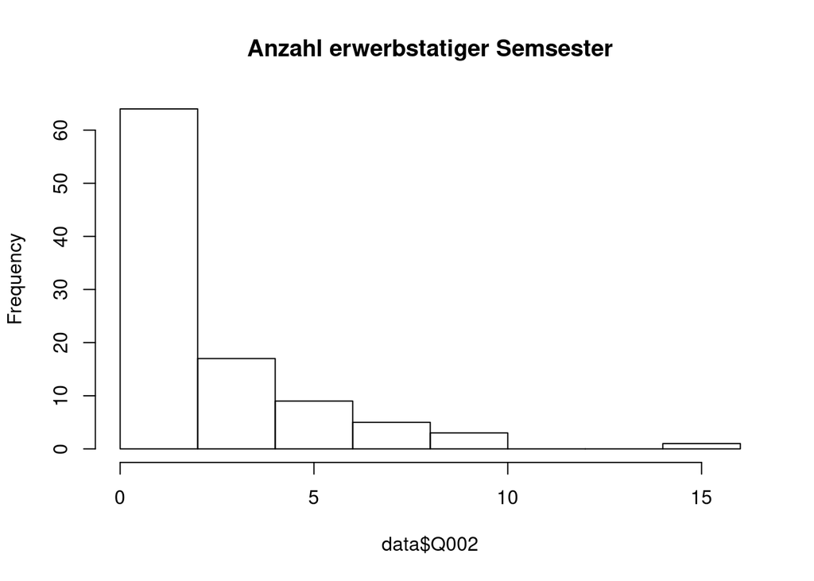

```r
data <- data[data$Q002 < 30,]
hist(data$Q002, main = "Anzahl erwerbstatiger Semsester")
```

someone had 333 semesters -> remove

```r
summary(data$Q003)
```

```
##    Min. 1st Qu.  Median    Mean 3rd Qu.    Max.
##   0.000   0.000   2.000   1.485   2.000   5.000
```

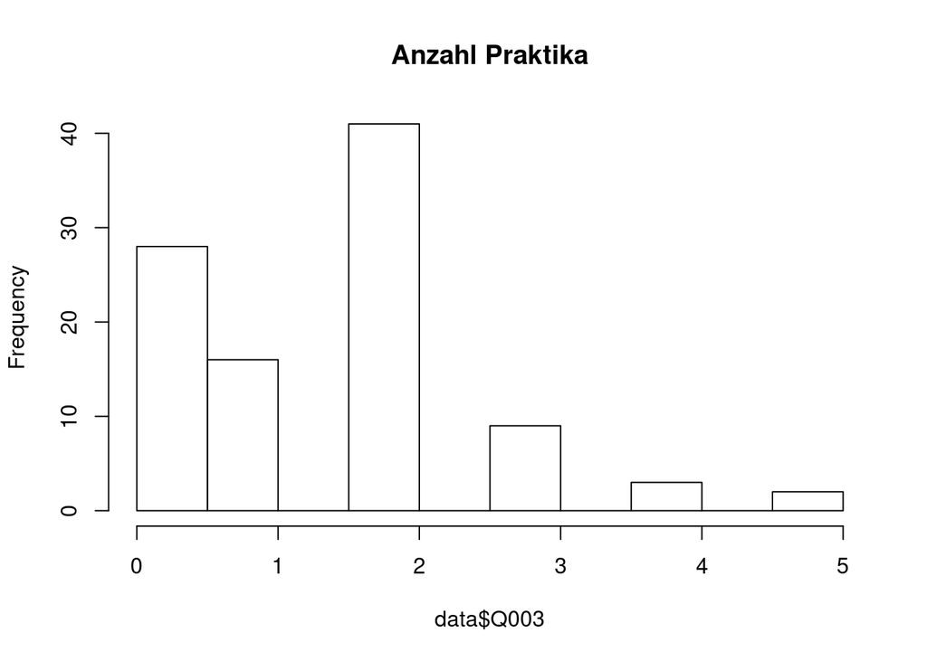

```r
hist(data$Q003, main = "Anzahl Praktika")
```

```r
summary(data$Q013)
```

```
##    Min. 1st Qu.  Median    Mean 3rd Qu.    Max.
##    19.0    21.0    22.0    22.7    24.0    35.0
```

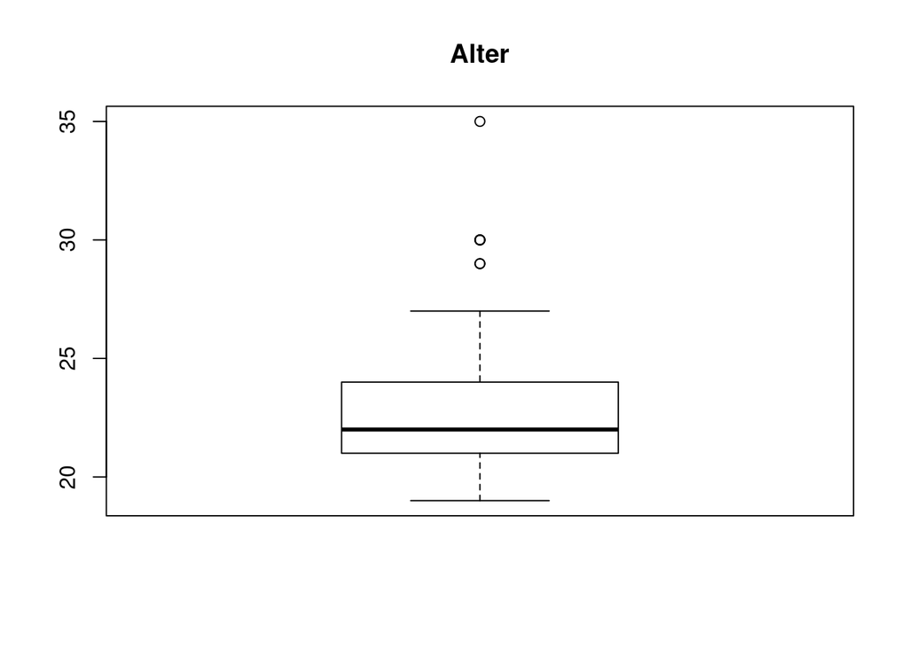

```r
boxplot(data$Q013, main = "Alter")
```

```r
summary(data$Q015)
```

```
##    Min. 1st Qu.  Median    Mean 3rd Qu.    Max.
##   0.000   3.000   6.000   5.737   8.000  14.000
```

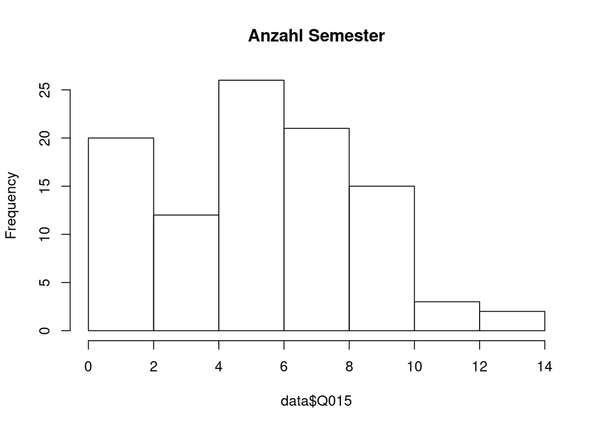

```r
hist(data$Q015, main = "Anzahl Semester")
```

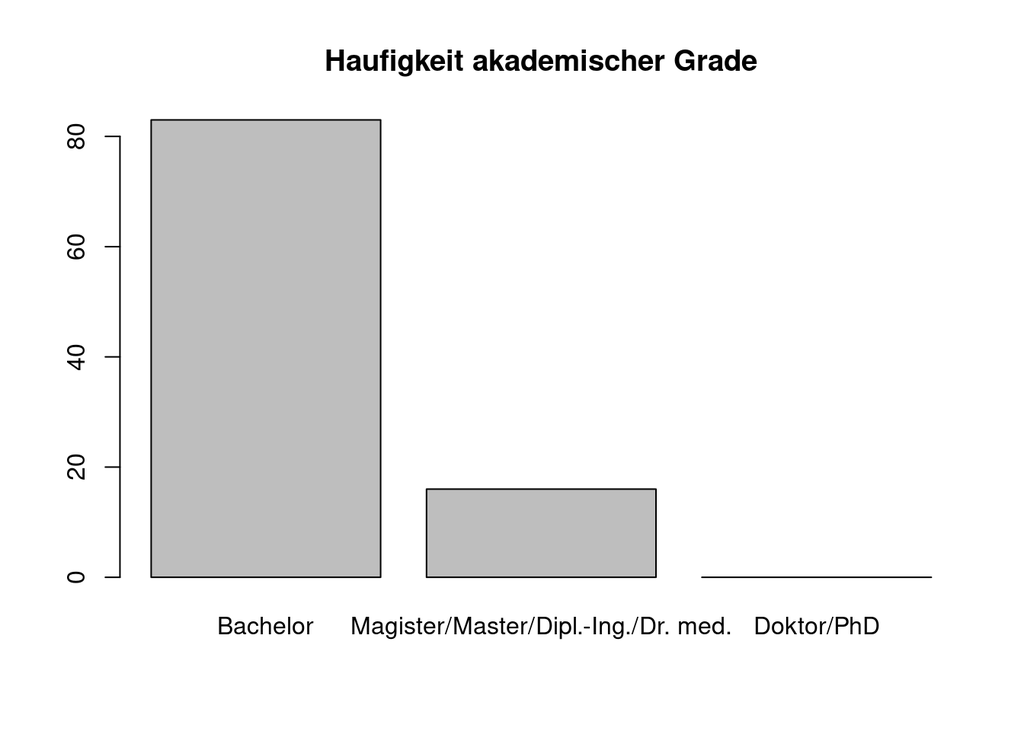

```r
plot(data$Q016, main = "Haufigkeit akademischer Grade")
```

```r
levels(data$Q016)[3] <- levels(data$Q016)[2]
```

No respondent was a doctor, so we remove this category.

```r
data["AnteilErwerbssemester"] <- data$Q002 / data$Q015
paste("Students with working semesters > 0 but semesters = 0: ", sum(is.infinite(data$AnteilErwerbssemester)))
```

```
## [1] "Students with working semesters > 0 but semesters = 0:  1"
```

```r
data <- data[!is.infinite(data$AnteilErwerbssemester),]
data[is.nan(data$AnteilErwerbssemester),]$AnteilErwerbssemester <- 0
data[data$AnteilErwerbssemester > 1,]$AnteilErwerbssemester <- 1
```

someone had Erwerbssemester > 0 while Semester = 0, which is impossible -> remove

```r
data["PraktikaProSemester"] <- data$Q003 / data$Q015
paste("Students with internships > 0 but semesters = 0: ", sum(is.infinite(data$AnteilErwerbssemester)))
```

```
## [1] "Students with internships > 0 but semesters = 0:  0"
```

```r
data[is.infinite(data$PraktikaProSemester),]$PraktikaProSemester <- 1
data[is.nan(data$PraktikaProSemester),]$PraktikaProSemester <- 0
data[data$PraktikaProSemester > 1,]$PraktikaProSemester <- 1
```

## Dependent Variable

Explanations in karriereerwartung.Rmd

```r
pca.data <- data[,c("Q001_SQ003", "Q001_SQ005")]
indx <- sapply(pca.data, is.factor)
pca.data[indx] <- lapply(pca.data[indx], as.numeric)
pca.result <- principal(pca.data, nfactors = 1, scores = TRUE)
erfolg.scores <- pca.result$scores[,'PC1']
data["Erfolg"] <- erfolg.scores
```

## Hypothesis 1

More work during university -> higher aspiration for career success

### `Erwerbstätigkeit` index

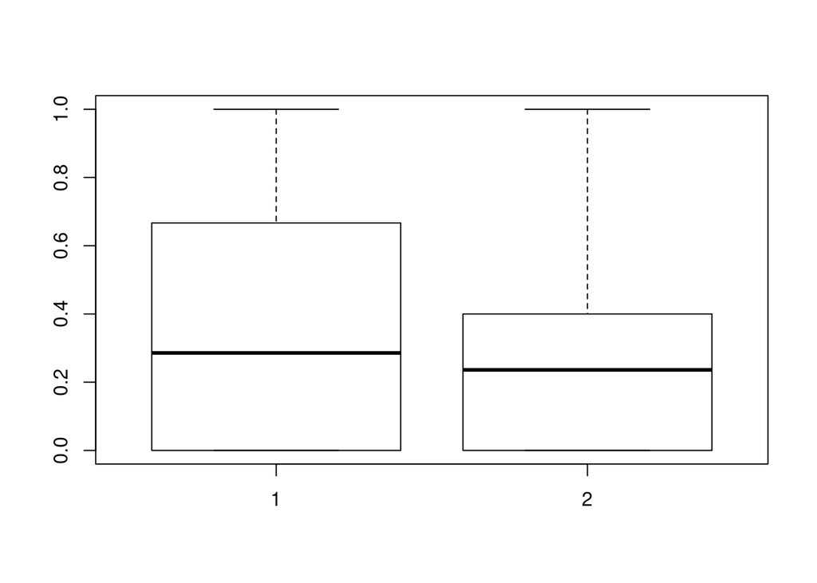

```r
erwerb.data <- data[,c("AnteilErwerbssemester", "PraktikaProSemester")]
boxplot(list(data$AnteilErwerbssemester, data$PraktikaProSemester))
```

```r
alpha(erwerb.data)
```

```
##
## Reliability analysis
## Call: alpha(x = erwerb.data)
##
##   raw_alpha std.alpha G6(smc) average_r  S/N  ase mean   sd median_r
##       0.11      0.11   0.061     0.061 0.13 0.17 0.32 0.23    0.061
##
##  lower alpha upper     95% confidence boundaries
## -0.23 0.11 0.44
##
##  Reliability if an item is dropped:
##                       raw_alpha std.alpha G6(smc) average_r S/N alpha se
## AnteilErwerbssemester    0.0606     0.061  0.0037     0.061  NA       NA
## PraktikaProSemester      0.0037     0.061      NA        NA  NA       NA
##                        var.r med.r
## AnteilErwerbssemester 0.0606 0.061
## PraktikaProSemester   0.0037 0.061
##
##  Item statistics
##                        n raw.r std.r r.cor r.drop mean   sd
## AnteilErwerbssemester 98  0.82  0.73  0.18  0.061 0.37 0.37
## PraktikaProSemester   98  0.62  0.73  0.18  0.061 0.27 0.26
```

```r
KMO(erwerb.data)
```

```
## Kaiser-Meyer-Olkin factor adequacy
## Call: KMO(r = erwerb.data)
## Overall MSA =  0.5
## MSA for each item =
## AnteilErwerbssemester   PraktikaProSemester
##                   0.5                   0.5
```

Anteil Erwerbssemester and Praktika pro Semester are not reliable measures (alpha = 0.11), KMO = 0.5 -> therefore PCA not really fitting

We decide to test the hypothesis for both individually -> no `Erwerbstätigkeit` index

### Test

Does the amount of semesters in which a student worked affect the aspiration for career success?

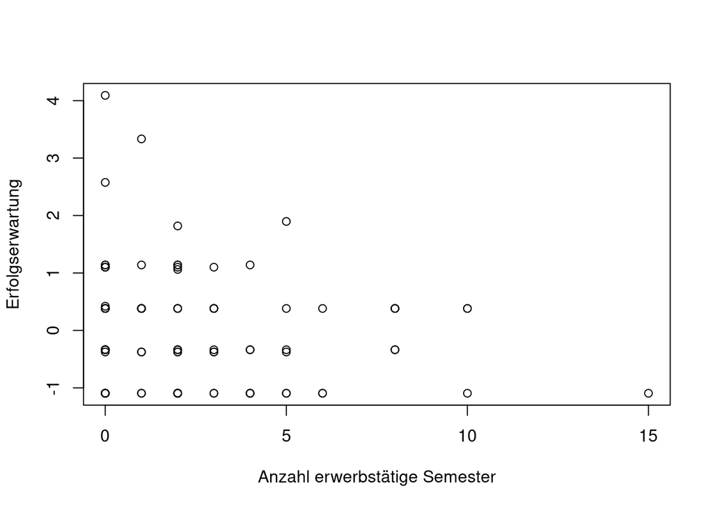

```r
plot(data$Q002, data$Erfolg, xlab = "Anzahl erwerbstätige Semester", ylab = "Erfolgserwartung")
```

The plot seems to show a slight negative correlation. We use a linear regression to see if this is significant. Our hypotheses using a significance level of $\alpha=0.05$ are:

- $H_0$: The regression coefficient of the variable `Anzahl erwerbstätige Semester` is 0. $\beta_{Anzahl erwerbstätige Semester} = 0$
- $H_A$: The regression coefficient of the variable `Anzahl erwerbstätige Semester` is different from 0. $\beta_{Anzahl erwerbstätige Semester} \neq 0$

```r
lm.result <- lm(Erfolg ~ Q002, data)
summary(lm.result)
```

```
##
## Call:
## lm(formula = Erfolg ~ Q002, data = data)
##
## Residuals:
##     Min      1Q  Median      3Q     Max
## -1.2255 -0.8451 -0.2431  0.4947  3.9591
##
## Coefficients:
##             Estimate Std. Error t value Pr(>|t|)
## (Intercept)  0.13196    0.13156   1.003    0.318
## Q002        -0.05434    0.03506  -1.550    0.124
##
## Residual standard error: 0.9929 on 96 degrees of freedom
## Multiple R-squared:  0.02441,    Adjusted R-squared:  0.01425
## F-statistic: 2.402 on 1 and 96 DF,  p-value: 0.1245
```

The result of the linear regression using ordinary least squares is that $\beta_{Anzahl erwerbstätige Semester}$ is not significantly different from 0, as the corresponding p-value is 0.124 > $\alpha$. Therefore, there is no evidence that the aspiration for career sucess is dependent upon the amount of semesters in which a student worked.

We still need to look at a few plots of the linear model to see if it is useful for our dataset.

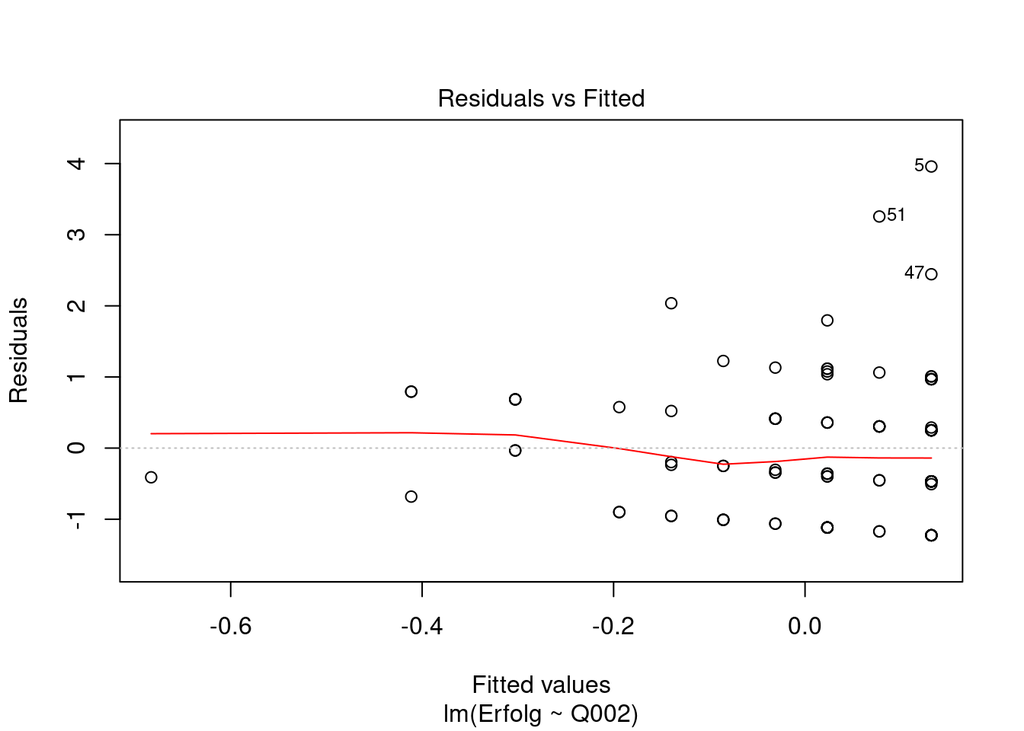

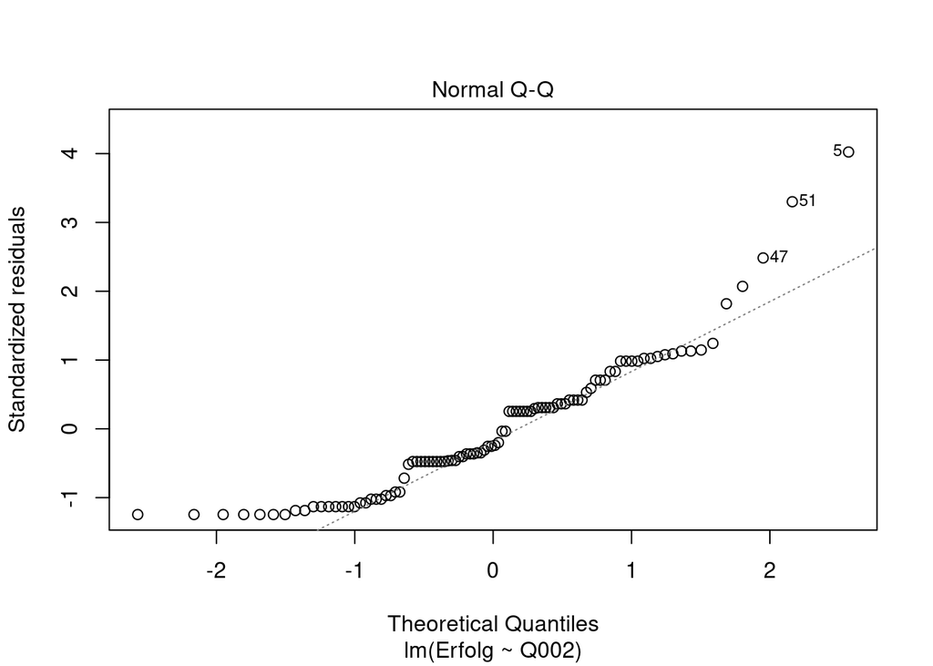

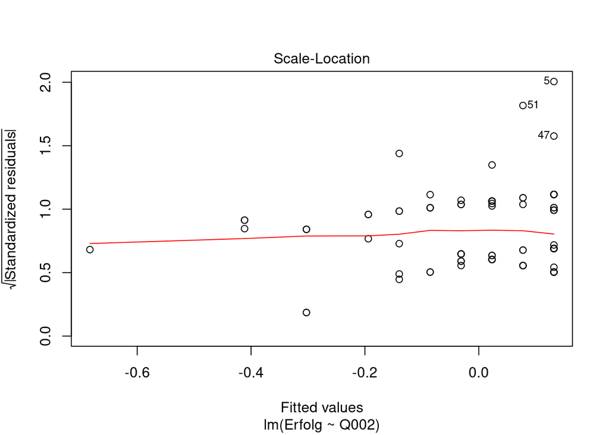

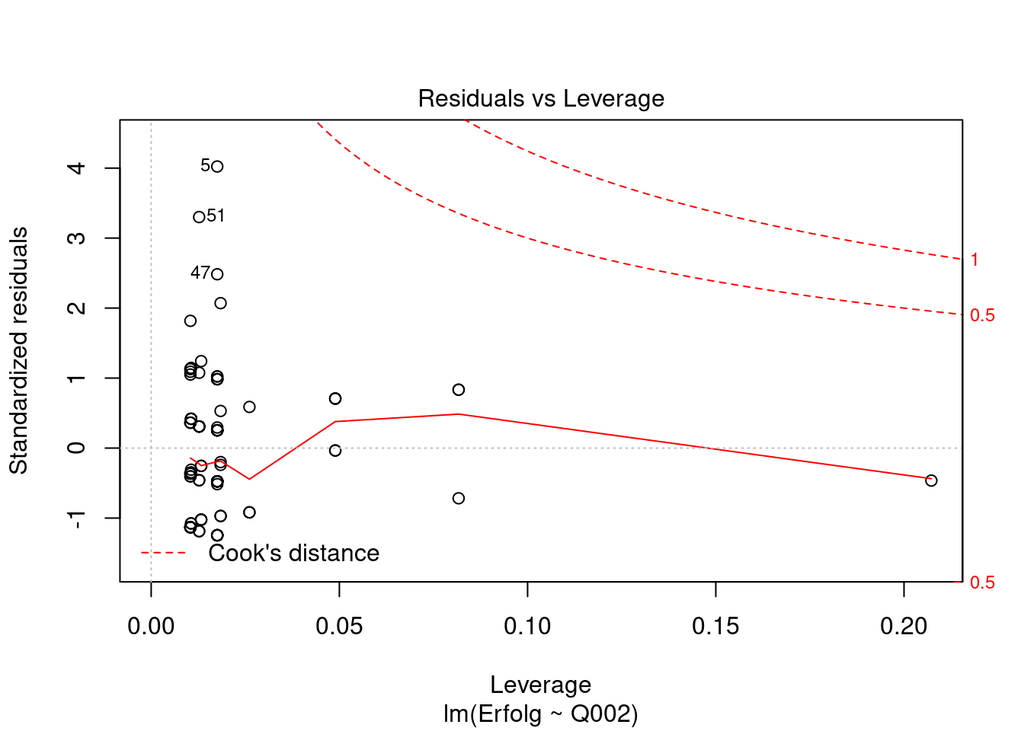

```r
plot(lm.result)
```

quantile-quantile not really god, residual plot ok

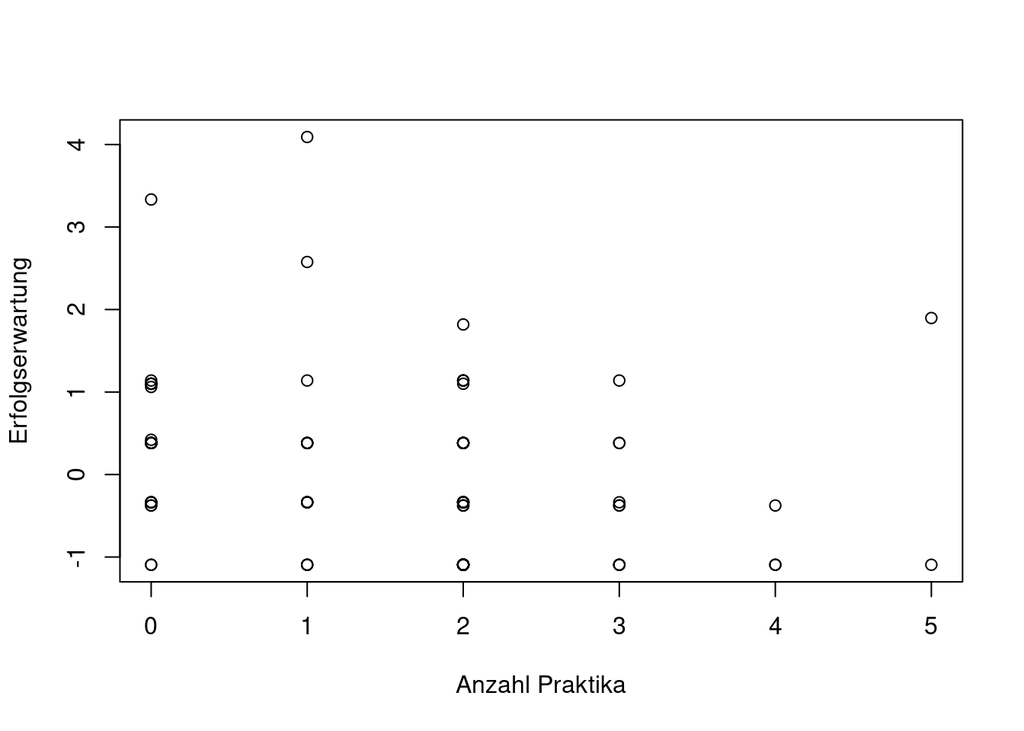

```r
plot(data$Q003, data$Erfolg, xlab = "Anzahl Praktika", ylab = "Erfolgserwartung")
```

```r
lm.result <- lm(Erfolg ~ Q003, data)
summary(lm.result)
```

```
##
## Call:
## lm(formula = Erfolg ~ Q003, data = data)
##
## Residuals:
##     Min      1Q  Median      3Q     Max
## -1.4393 -0.7210 -0.1251  0.4975  3.9758
##
## Coefficients:
##             Estimate Std. Error t value Pr(>|t|)
## (Intercept)  0.34582    0.15715   2.201  0.03017 *
## Q003        -0.23055    0.08211  -2.808  0.00604 **
## ---
## Signif. codes:  0 '***' 0.001 '**' 0.01 '*' 0.05 '.' 0.1 ' ' 1
##
## Residual standard error: 0.9663 on 96 degrees of freedom
## Multiple R-squared:  0.07589,    Adjusted R-squared:  0.06627
## F-statistic: 7.884 on 1 and 96 DF,  p-value: 0.006042
```

significant: the more internships, the less Erfolg aspiration -> our hypothesis is false

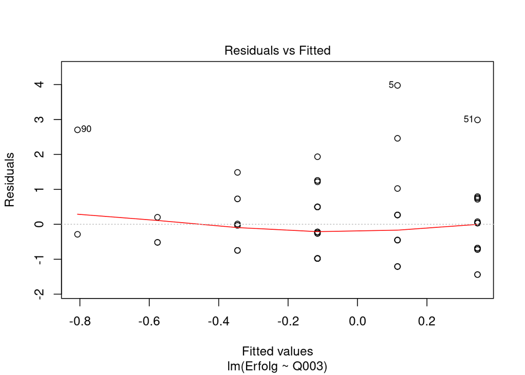

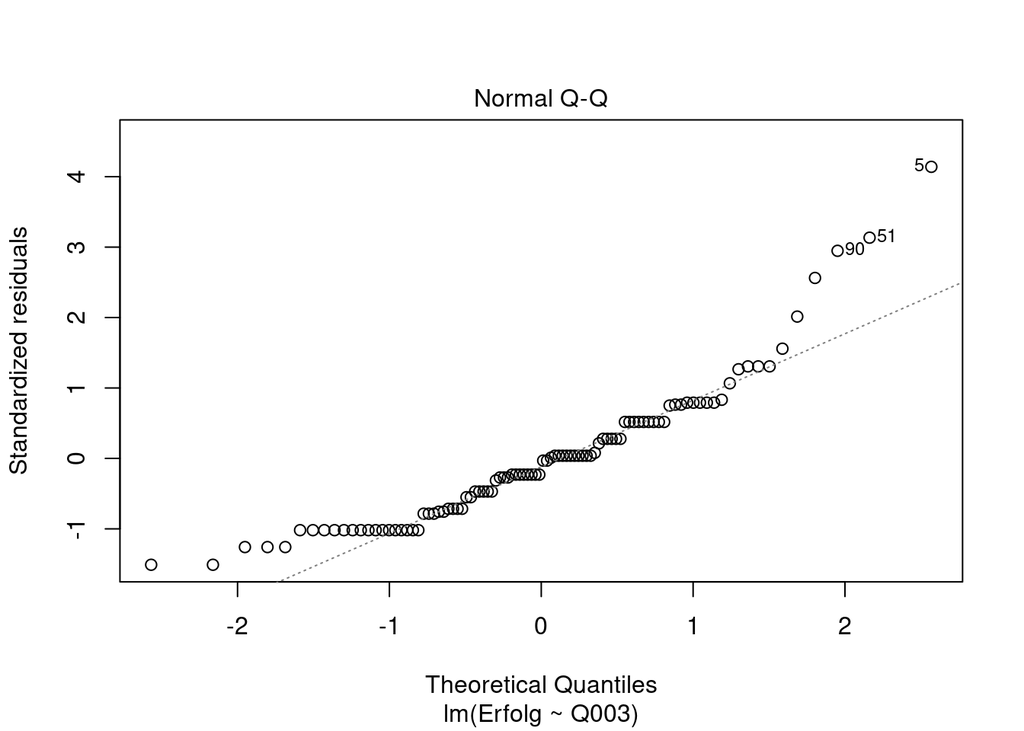

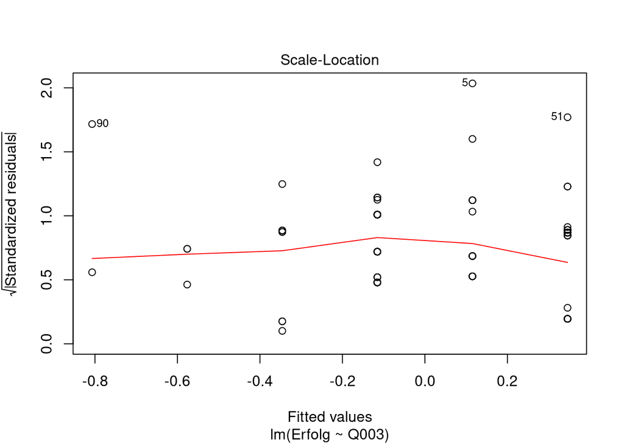

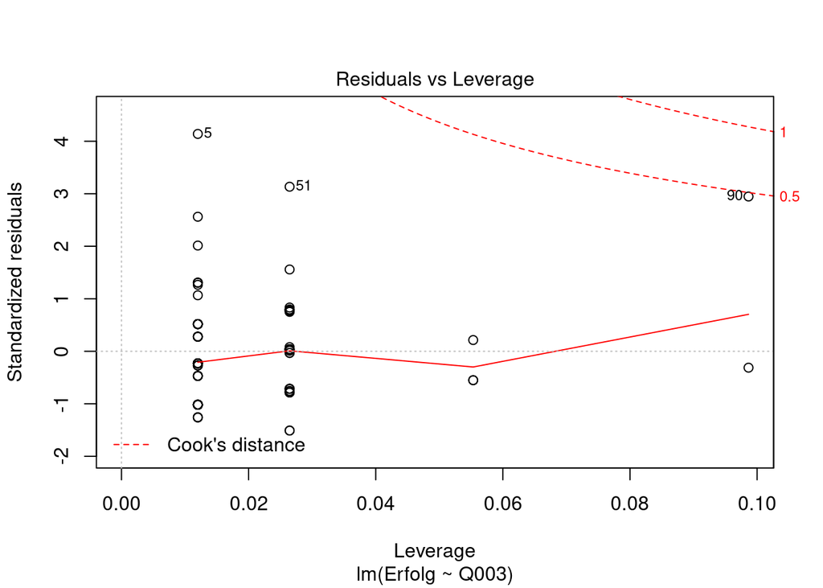

```r
plot(lm.result)
```

quantile-quantile not really god, residual plot ok

## Hypothesis 2

higher support of parents -> higher aspiration for career success

```r
support.data <- data[,c("Q004_SQ001", "Q004_SQ002", "Q004_SQ003", "Q004_SQ004", "Q004_SQ005", "Q004_SQ006", "Q004_SQ007")]
support.data <- factors.as.numeric(support.data)
alpha(support.data)
```

```
##
## Reliability analysis
## Call: alpha(x = support.data)
##
##   raw_alpha std.alpha G6(smc) average_r S/N   ase mean   sd median_r
##       0.86      0.85    0.86      0.45 5.7 0.021    2 0.95     0.51
##
##  lower alpha upper     95% confidence boundaries
## 0.82 0.86 0.9
##
##  Reliability if an item is dropped:
##            raw_alpha std.alpha G6(smc) average_r S/N alpha se var.r med.r
## Q004_SQ001      0.88      0.88    0.88      0.55 7.4    0.019 0.011  0.58
## Q004_SQ002      0.81      0.80    0.81      0.40 4.1    0.029 0.032  0.45
## Q004_SQ003      0.82      0.81    0.82      0.42 4.4    0.027 0.035  0.45
## Q004_SQ004      0.83      0.82    0.84      0.44 4.7    0.025 0.050  0.51
## Q004_SQ005      0.83      0.82    0.83      0.43 4.5    0.026 0.045  0.47
## Q004_SQ006      0.85      0.84    0.85      0.47 5.2    0.023 0.041  0.51
## Q004_SQ007      0.83      0.83    0.83      0.44 4.7    0.025 0.042  0.47
##
##  Item statistics
##             n raw.r std.r r.cor r.drop mean  sd
## Q004_SQ001 98  0.39  0.43  0.28   0.24  1.9 1.1
## Q004_SQ002 98  0.87  0.86  0.87   0.81  2.2 1.3
## Q004_SQ003 98  0.82  0.81  0.80   0.73  2.1 1.4
## Q004_SQ004 98  0.75  0.76  0.70   0.65  2.3 1.3
## Q004_SQ005 98  0.79  0.79  0.75   0.70  2.0 1.2
## Q004_SQ006 98  0.70  0.68  0.61   0.57  1.8 1.4
## Q004_SQ007 98  0.77  0.76  0.71   0.66  2.0 1.4
##
## Non missing response frequency for each item
##               1    2    3    4    5 miss
## Q004_SQ001 0.46 0.27 0.21 0.02 0.04    0
## Q004_SQ002 0.45 0.24 0.10 0.11 0.09    0
## Q004_SQ003 0.50 0.21 0.11 0.06 0.11    0
## Q004_SQ004 0.37 0.26 0.21 0.07 0.09    0
## Q004_SQ005 0.46 0.31 0.09 0.07 0.07    0
## Q004_SQ006 0.62 0.18 0.04 0.04 0.11    0
## Q004_SQ007 0.56 0.18 0.05 0.10 0.10    0
```

```r
KMO(support.data)
```

```
## Kaiser-Meyer-Olkin factor adequacy
## Call: KMO(r = support.data)
## Overall MSA =  0.85
## MSA for each item =
## Q004_SQ001 Q004_SQ002 Q004_SQ003 Q004_SQ004 Q004_SQ005 Q004_SQ006
##       0.68       0.81       0.81       0.88       0.91       0.88
## Q004_SQ007
##       0.87
```

good alpha and KMO -> PCA

```r
support.data <- support.data[-1]
support.names <- c("Books", "Fees", "Travel", "Food", "Allowance", "Expenses")
alpha(support.data)
```

```
##
## Reliability analysis
## Call: alpha(x = support.data)
##
##   raw_alpha std.alpha G6(smc) average_r S/N   ase mean  sd median_r
##       0.88      0.88    0.88      0.55 7.4 0.019  2.1 1.1     0.58
##
##  lower alpha upper     95% confidence boundaries
## 0.84 0.88 0.92
##
##  Reliability if an item is dropped:
##            raw_alpha std.alpha G6(smc) average_r S/N alpha se  var.r med.r
## Q004_SQ002      0.84      0.84    0.82      0.51 5.2    0.026 0.0058  0.51
## Q004_SQ003      0.85      0.85    0.83      0.53 5.7    0.024 0.0080  0.55
## Q004_SQ004      0.87      0.87    0.87      0.58 6.9    0.021 0.0104  0.58
## Q004_SQ005      0.86      0.86    0.85      0.55 6.1    0.023 0.0141  0.56
## Q004_SQ006      0.88      0.88    0.87      0.59 7.1    0.020 0.0099  0.59
## Q004_SQ007      0.86      0.86    0.85      0.56 6.3    0.022 0.0147  0.56
##
##  Item statistics
##             n raw.r std.r r.cor r.drop mean  sd
## Q004_SQ002 98  0.88  0.88  0.88   0.82  2.2 1.3
## Q004_SQ003 98  0.84  0.84  0.82   0.75  2.1 1.4
## Q004_SQ004 98  0.73  0.74  0.65   0.61  2.3 1.3
## Q004_SQ005 98  0.79  0.80  0.74   0.70  2.0 1.2
## Q004_SQ006 98  0.72  0.72  0.63   0.59  1.8 1.4
## Q004_SQ007 98  0.79  0.78  0.72   0.68  2.0 1.4
##
## Non missing response frequency for each item
##               1    2    3    4    5 miss
## Q004_SQ002 0.45 0.24 0.10 0.11 0.09    0
## Q004_SQ003 0.50 0.21 0.11 0.06 0.11    0
## Q004_SQ004 0.37 0.26 0.21 0.07 0.09    0
## Q004_SQ005 0.46 0.31 0.09 0.07 0.07    0
## Q004_SQ006 0.62 0.18 0.04 0.04 0.11    0
## Q004_SQ007 0.56 0.18 0.05 0.10 0.10    0
```

```r
KMO(support.data)
```

```
## Kaiser-Meyer-Olkin factor adequacy
## Call: KMO(r = support.data)
## Overall MSA =  0.86
## MSA for each item =
## Q004_SQ002 Q004_SQ003 Q004_SQ004 Q004_SQ005 Q004_SQ006 Q004_SQ007
##       0.81       0.81       0.93       0.91       0.88       0.86
```

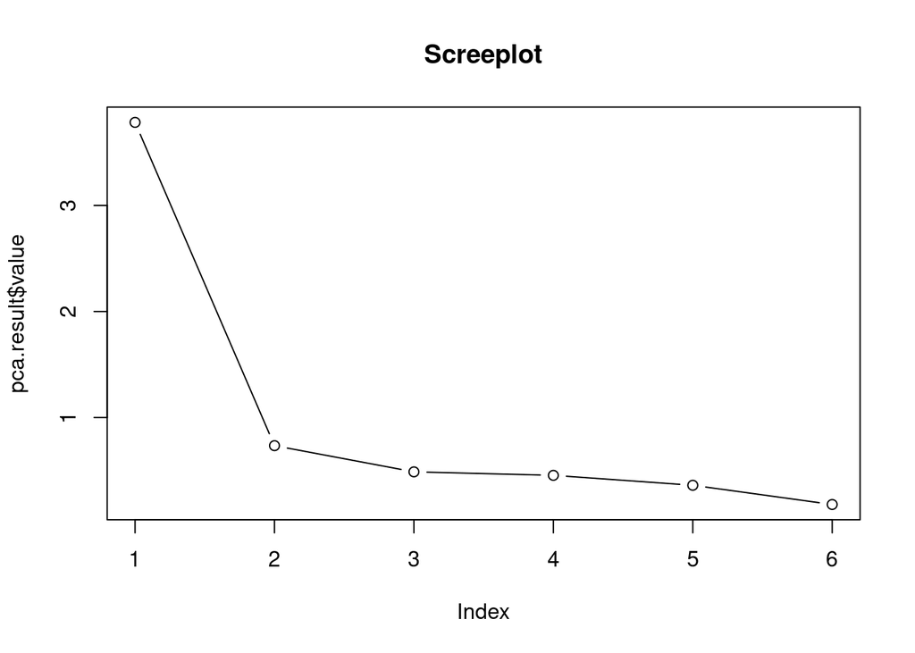

```r
pca.result <- principal(support.data, nfactors = 1, scores = TRUE)
support.scores <- pca.result$scores[,'PC1']
data["HilfeEltern"] <- support.scores
plot(pca.result$value, type = 'b', main = 'Screeplot')
```

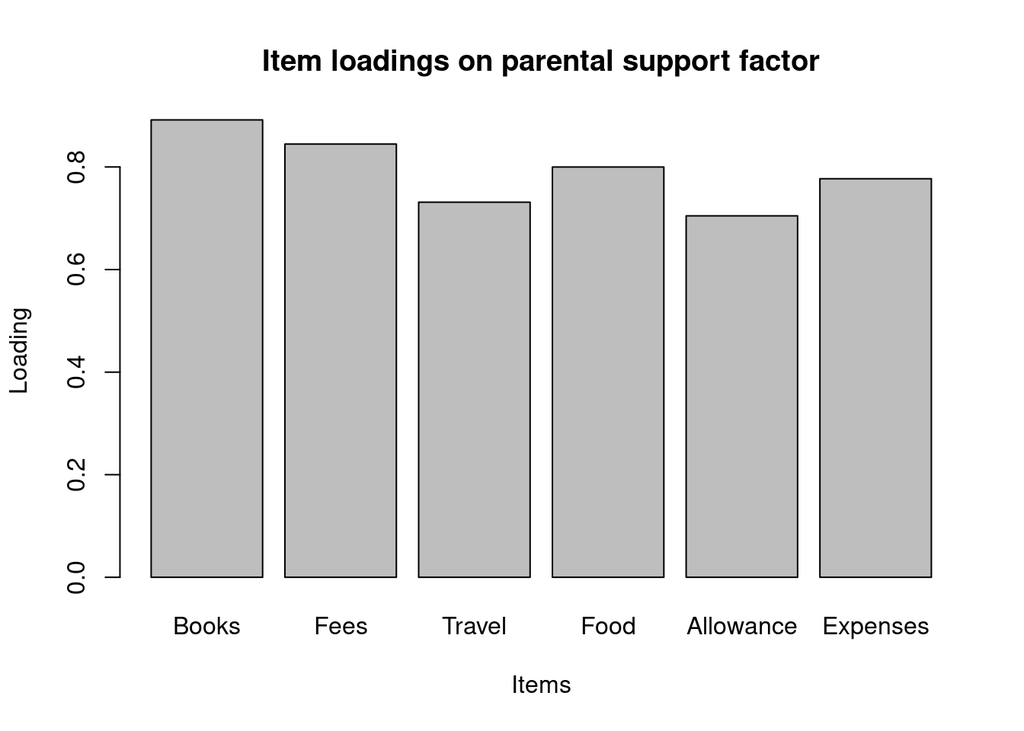

```r
barplot(pca.result$loadings[,1], names.arg = support.names, main = "Item loadings on parental support factor", ylab = "Loading", xlab = "Items")
```

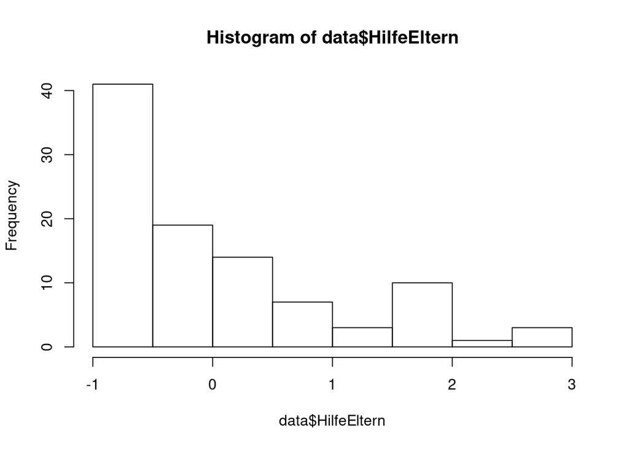

```r
hist(data$HilfeEltern)
```

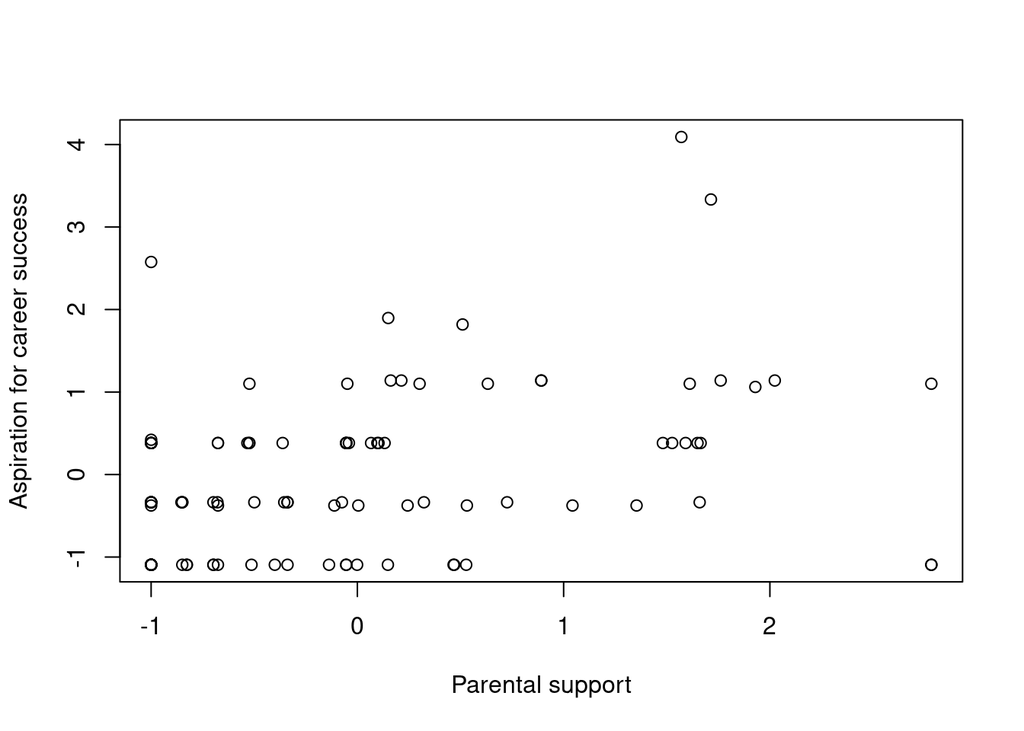

```r
plot(data$HilfeEltern, data$Erfolg, xlab = "Parental support", ylab = "Aspiration for career success")
```

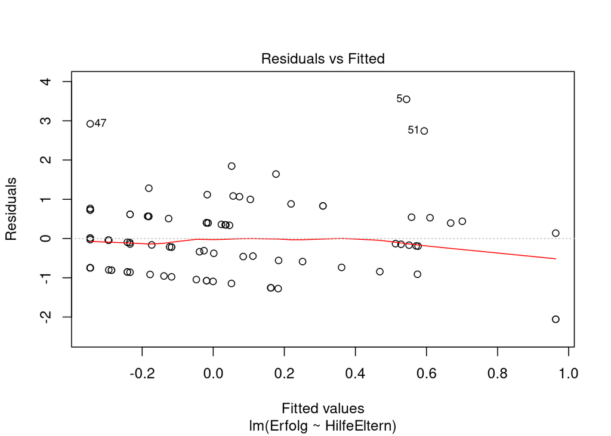

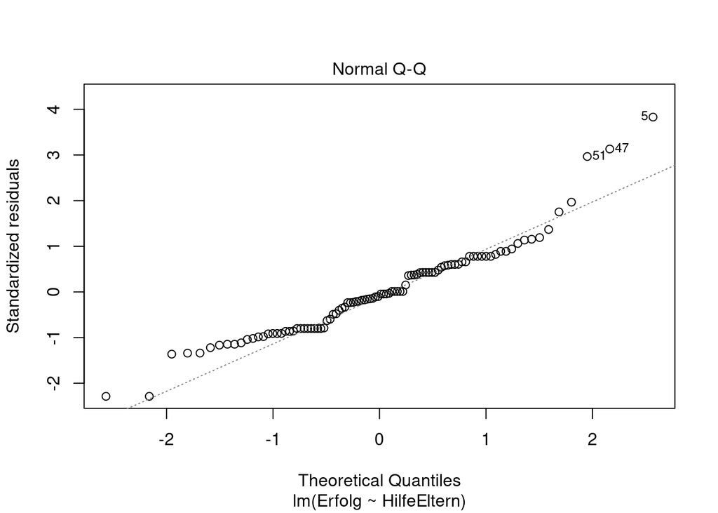

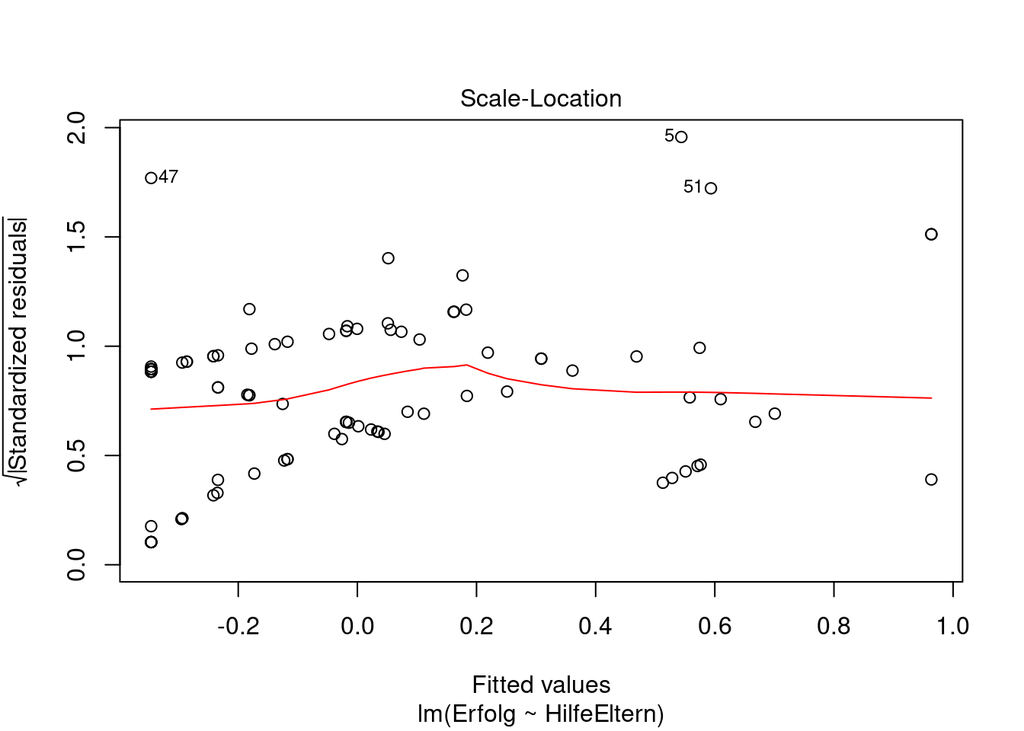

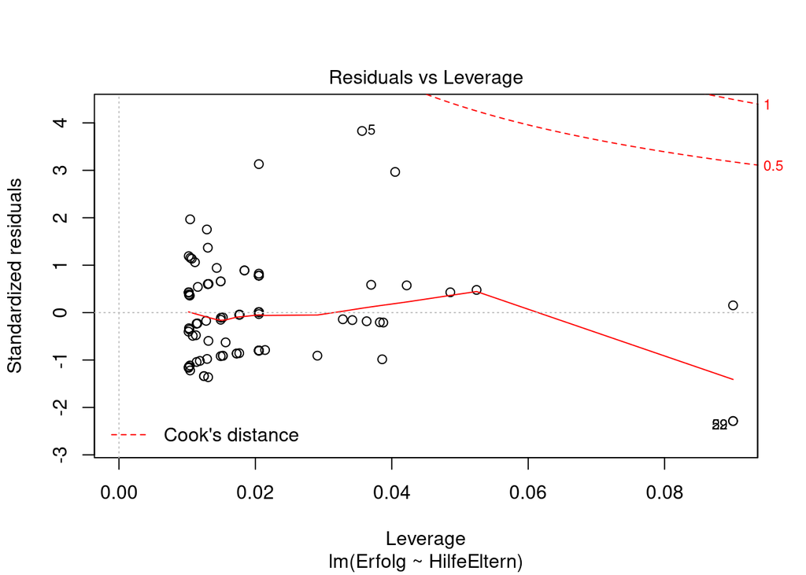

```r
lm.result <- lm(Erfolg ~ HilfeEltern, data)
plot(lm.result)
```

quantile and residual plots suggest that the linear model fits the data

```r
summary(lm.result)
```

```
##
## Call:
## lm(formula = Erfolg ~ HilfeEltern, data = data)
##
## Residuals:
##     Min      1Q  Median      3Q     Max
## -2.0570 -0.7474 -0.0683  0.5582  3.5472
##
## Coefficients:
##               Estimate Std. Error t value Pr(>|t|)
## (Intercept) -1.924e-16  9.526e-02   0.000 1.000000
## HilfeEltern  3.462e-01  9.575e-02   3.616 0.000479 ***
## ---
## Signif. codes:  0 '***' 0.001 '**' 0.01 '*' 0.05 '.' 0.1 ' ' 1
##
## Residual standard error: 0.943 on 96 degrees of freedom
## Multiple R-squared:  0.1199, Adjusted R-squared:  0.1107
## F-statistic: 13.08 on 1 and 96 DF,  p-value: 0.0004792
```

As the p-value is lower than $\alpha$, we know that $\beta_{parental support}$ is significantly different from 0. As the estimate of $\beta_{parental support}$ is positive, we know that more support of parents leads to a higher aspiration for career success.

## Hypothesis 3

higher cost of living -> higher aspiration for career success

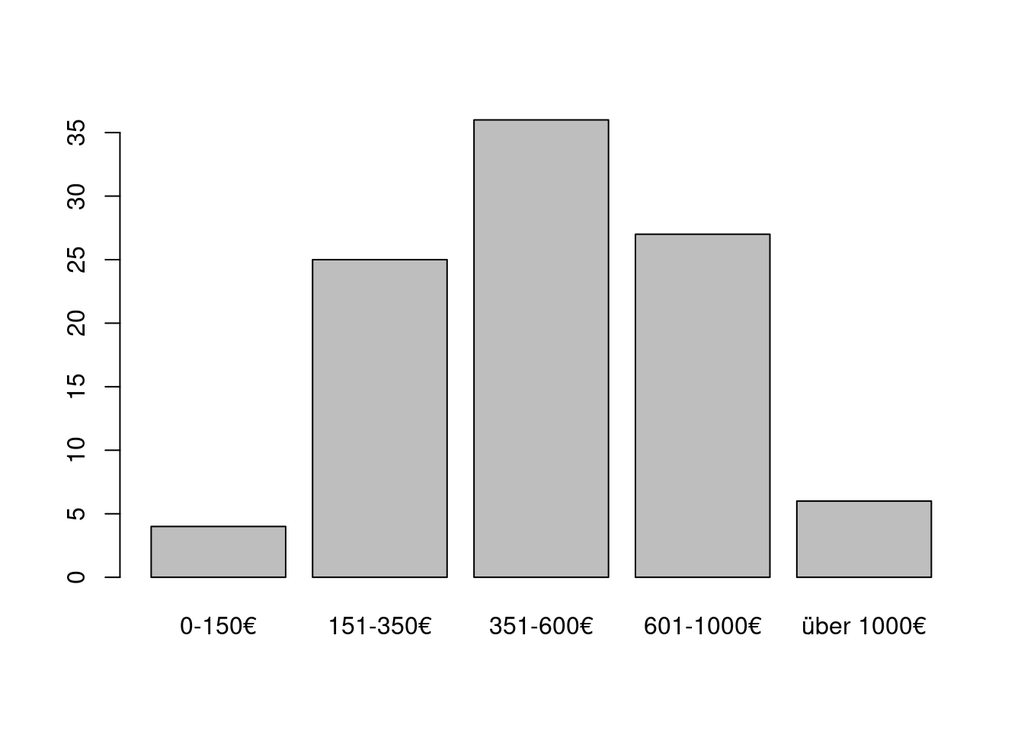

```r
plot(data$Q005)
```

ordinal scale

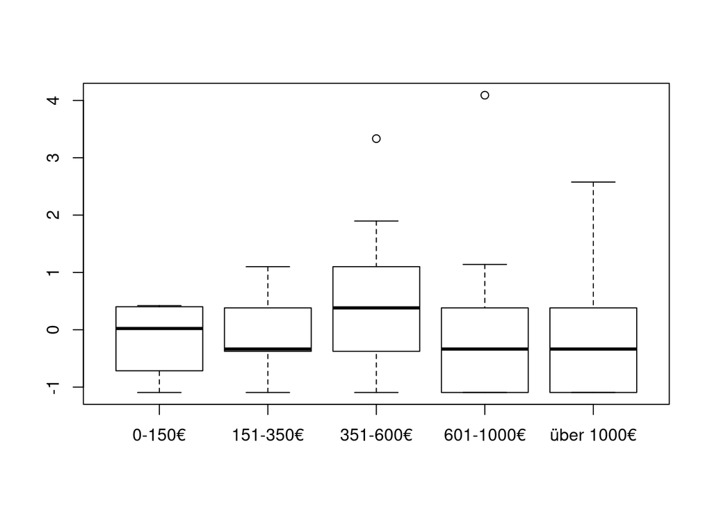

```r
boxplot(Erfolg ~ Q005, data)
```

medians do not seem to differ a lot

since only 351-600 is normally distributed, we need to use a robust test -> Kruskall-Wallis test:

```r
kruskal.test(Erfolg ~ Q005, data)
```

```
##
##  Kruskal-Wallis rank sum test
##
## data:  Erfolg by Q005
## Kruskal-Wallis chi-squared = 4.8406, df = 4, p-value = 0.304
```

insignificant -> median is not different in groups -> no evidence that aspiration for career success is dependent on cost of living

## Hypothesis 4

higher social assistance -> less aspiration for career success

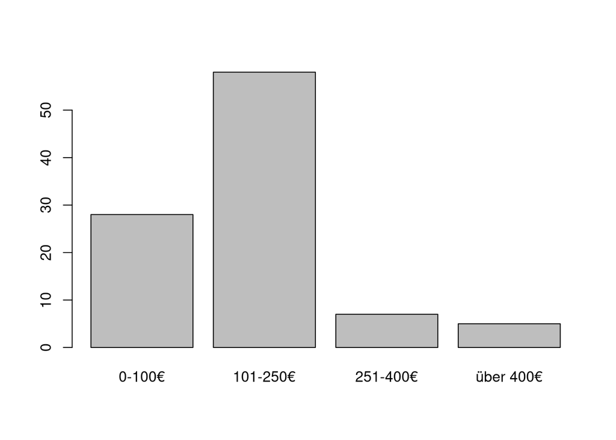

```r
plot(data$Q006)
```

ordinal scale

```r
levels(data$Q006)[4] <- levels(data$Q006)[3]
levels(data$Q006)[3] <- "über 250€"
```

too few occurences for the last two categories, so we combine them

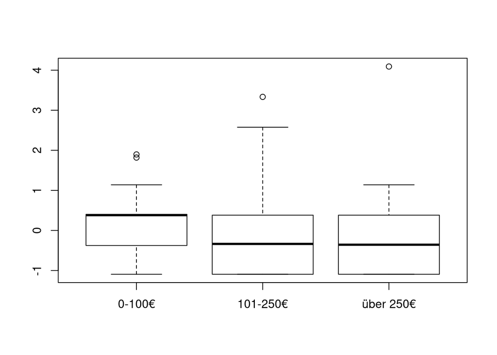

```r
boxplot(Erfolg ~ Q006, data)
```

The median in category `0-100€` seems the be higher than the other medians. As the categories are not normally distributed, we use a Kruskall-Wallis test to investigate this.

```r
kruskal.test(Erfolg ~ Q006, data)
```

```
##
##  Kruskal-Wallis rank sum test
##
## data:  Erfolg by Q006
## Kruskal-Wallis chi-squared = 1.4459, df = 2, p-value = 0.4853
```

insignificant -> median is not different in groups -> no evidence that aspiration for career success is dependent on social assistance

## Hypothesis 5

more grants -> higher aspiration for career success

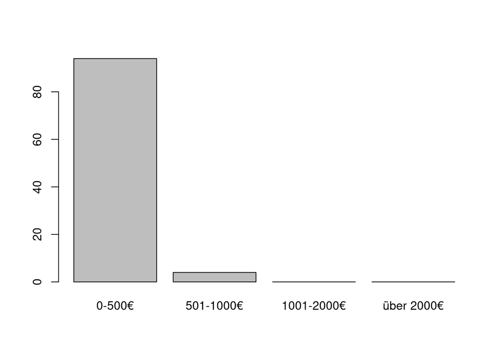

```r
plot(data$Q007)
```

ordinal scale

```r
summary(data$Q007)
```

```
##     0-500€  501-1000€ 1001-2000€ über 2000€
##         94          4          0          0
```

only four respondents receive grants -> too small sample

```r
levels(data$Q007)[4] <- levels(data$Q007)[2]
levels(data$Q007)[3] <- levels(data$Q007)[2]
levels(data$Q007)[2] <- "ja"
levels(data$Q007)[1] <- "nein"
```

convert into dichotomous variable: receive grant yes or no

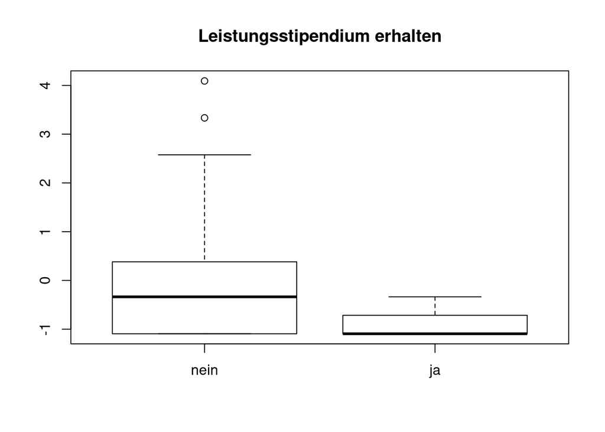

```r
boxplot(Erfolg ~ Q007, data, main = "Leistungsstipendium erhalten")
```

There seems to be a significant difference in the medians. Apparently, students who receive grants have less aspiration for career success.

We use a statistical test to see if this holds up. Since both groups are not normally distributed, we need to use the robust Kruskall-Wallis test.

Our test hypotheses using a significance level $\alpha=0.05$ are:

- $H_0: \mu^{Erfolg}_{kein Leistungsstipendium} = \mu^{Erfolg}_{Leistungsstipendium erhalten}$
- $H_A: \mu^{Erfolg}_{kein Leistungsstipendium} \neq \mu^{Erfolg}_{Leistungsstipendium erhalten}$

```r
kruskal.test(Erfolg ~ Q007, data)
```

```
##
##  Kruskal-Wallis rank sum test
##
## data:  Erfolg by Q007
## Kruskal-Wallis chi-squared = 4.2041, df = 1, p-value = 0.04033
```

The p-value is 0.04, which is lower than our $\alpha$. Therefore, we can accept $H_A$. There is evidence that students who receive grants have significantly lower aspiration for career success.

## Hypothesis 6

more available financial capital -> higher aspiration for career success

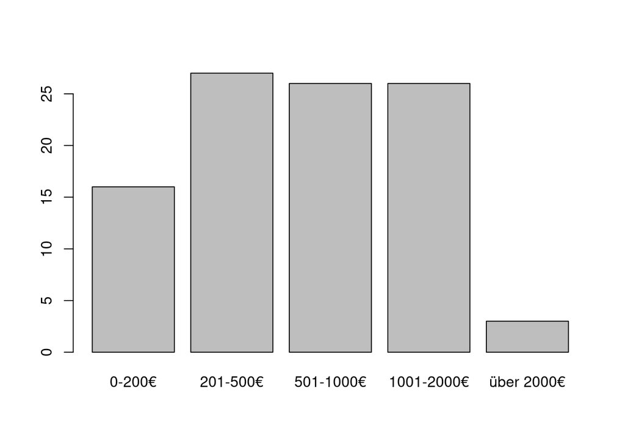

```r
plot(data$Q008)
```

ordinal scale

```r
levels(data$Q008)[5] <- levels(data$Q008)[4]
levels(data$Q008)[4] <- "über 1000€"
```

We see that only three observations fall into the `über 2000€` category. We therefore decided to combine this level with the `1001-2000€` level. The newly created level is simply called `über 1000`.

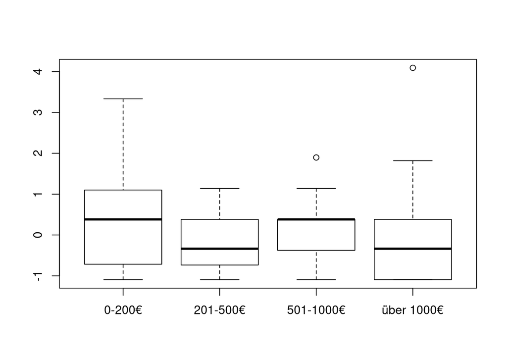

```r
boxplot(Erfolg ~ Q008, data)
```

medians do not seem to differ a lot

since no category is normally distributed, we need to use a robust test -> Kruskall-Wallis test:

```r
kruskal.test(Erfolg ~ Q008, data)
```

```
##
##  Kruskal-Wallis rank sum test
##
## data:  Erfolg by Q008
## Kruskal-Wallis chi-squared = 4.4156, df = 3, p-value = 0.2199
```

insignificant -> median is not different in groups -> no evidence that aspiration for career success is dependent on available financial capital